# Lernzettel

## Lagrange Formalismus

Beschreibung der Mechanik allgemeiner, mit Betrachtung von Zwangsbedingungen. Nach Newton müsste man Zwangskräfte, wie den Pfaden eines Pendels erst einberechnen um dann am Ende wieder zu eliminieren.

Beschreibt man ein System mit n Freiheitsgeraden hingegen allgemein durch n generalisierte Koordinaten und ihre Geschwindigkeiten $q_1, \dot q_1 ... q_n, \dot q_n$, so kann man sich viele Koordinaten (nach Newton etwa 3 Dimensionen) sparen. Für ein Pendel z. B. seien die generalisierte Koordinate einfach die Auslenkung $\varphi, \dot \varphi$, da der Radius fest wäre und man braucht so nur eine. Die Koordinaten müssen also nicht kartesisch sein, man muss mit ihnen aber die kinetische und die potenzielle Energie definieren können.

Denn drückt man in Abhängigkeit von $q, \dot q$ nun die kinetische $T$ und die potenzielle $U$ Energie aus, so erhält man direkt die Lagrangefunktion definiert als:

#### Lagrangefunktion

$$L(q,\dot q) = T(q,\dot q) - U(q)$$

Diese ist von hoher Bedeutung für uns da man unter verwendung dieser direkt die Differentialgleichungen der Bewegungsgleichungen für alle n Freiheitsgerade erhält. Herleitung und Beweis dieser **Euler-Lagrange Gleichung**ist im folgenden aufgeführt.

##### Euler-Lagrange Gleichung

$\forall \; i = 1, ... N:$ $$ \frac{d}{dt} \frac{\partial L(q, \dot q)}{\partial \dot q_i} - \frac{\partial L(q, \dot q)}{\partial q_i} = 0 $$

$\frac{\partial L}{\partial \dot q}$ wird dabei auch generalisierter Impuls $p$ genannt. Damit gelte: $$\frac{dp_i}{dt} = \frac{\partial L}{\partial q_i}$$

#### Herleitung per Hamilton'schem Prinzip

Die Natur folgt "Extrema", und so können wir hier mithilfe des Variations-Prinzips argumentieren. Führen wir den Begriff Wirkung als Funktional S zu jeder denkbaren Trajektorie $q$ ein

$$ S[q(t)] = \int_{a}^{b} L(q, \dot q)\;dt $$

so können wir formulieren, dass das System zwischen zwei Punkten $(t = a, q = q_a), (t = b, q = q_b)$ jene Trajektorie annimmt, längs der die Wirkung S stationär ist - die Wirkung also ein Extrema annimmt. Die Ableitung der Wirkung nach der Stärke der Varitation ist also null, das heißt eine infinitisimal kleine Änderung der Trajektorie q zu einer Variation q' verändert nicht die Wirkung.

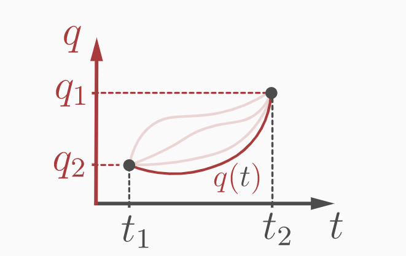

Formalisieren wir die Variation einer Trajektorie $q'$ können wir die obige forderung an die Wirkung mathematisch formulieren. Definieren wir unsere variierte Trajektorie mit

$$\begin{align} q'(t, \alpha) = q(t) + \alpha \cdot \eta (t)\\ \Rightarrow \dot q'(t, \alpha) = q(t) + \alpha \cdot \dot \eta (t) \end{align} $$

unter Zuhilfenahme einer beliebigen Funktion $\eta(t)$, wobei $\eta(a) = \eta(b) = 0$ damit Start und Endpunkt unverändert bleiben, so hängt die Stärke der Variation von $\alpha$ ab und um die Extrema-Bedingung zu erfüllen, fordern wir für $\alpha = 0 $

$$\frac{\partial S[q'(t, \alpha)]}{\partial \alpha} \stackrel{!}{=}0.$$

Dies erfordert direkt, die oben stehenden Differenzialgleichungen: $ \frac{d}{dt} \frac{\partial L(q, \dot q)}{\partial \dot q_i} - \frac{\partial L(q, \dot q)}{\partial q_i} = 0 $ wie wir im Folgenden zeigen.

#### Nachweis

$L(q', \dot q') = L(q + \alpha \eta, \dot q + \alpha \dot \eta) $ erhalten wir ungefähr aus der Taylorentwicklung um $\alpha = 0$ herum:

$$ \begin{align} L(q + \alpha \eta, \dot q + \alpha \dot \eta) & = L(q + 0 \cdot \eta, \dot q + 0 \cdot \dot \eta) + \alpha \cdot \frac{\partial L(q + \alpha \eta, \dot q + \alpha \dot \eta) }{\partial \alpha} + O(\alpha^2)\\ & =L(q , \dot q) + \alpha \cdot \frac{\partial L(q + \alpha \eta, \dot q + \alpha \dot \eta) }{\partial \alpha} + O(\alpha^2) \end{align} $$

Um das totale Differenzial von $\frac{\partial L(q + \alpha \eta, \dot q + \alpha \dot \eta) }{\partial \alpha} $ zu berechnen nutzen wir, dass für $(x,y) \mapsto f(x, y)$

$$ df = \frac{\partial f}{\partial x} dx + \frac{\partial f}{\partial y} dy $$

gilt. Wir erhalten:

$$ \frac{\partial L(q + \alpha \eta, \dot q + \alpha \dot \eta) }{\partial \alpha} = \frac{\partial L}{\partial (q + \alpha \eta)} + \frac{\partial L}{\partial(\dot q + \alpha \dot \eta)} $$

Dies lösen wir mit der Kettenregel:

$$ \begin{align} \frac{\partial L}{\partial (q + \alpha \eta)} + \frac{\partial L}{\partial(\dot q + \alpha \dot \eta)} & = \frac{\partial L} {\partial q} \cdot \frac{(\partial q + \alpha \eta)}{\partial \alpha} + \frac{\partial L}{\partial \dot q} \cdot \frac{(\partial \dot q + \alpha \dot \eta)}{\partial \alpha}\\ & = \frac{\partial L}{\partial q} \cdot \eta + \frac{\partial L}{\partial \dot q} \cdot \dot \eta \end{align} $$

wir setzen die Ableitung in den Summanden der Taylor Entwicklung ein:

$$L(q , \dot q) + \alpha \cdot (\frac{\partial L}{\partial q} \cdot \eta + \frac{\partial L}{\partial \dot q} \cdot \dot \eta ) + O(\alpha^2)$$

Um nun mit dem Integral die Wirkung berechnen zu können:

$$ S[q(t)] = \int_{a}^{b} L(q , \dot q) + \alpha \cdot \frac{\partial L}{\partial q} \cdot \eta + \alpha \cdot \frac{\partial L}{\partial \dot q} \cdot \dot \eta \;dt + O(\alpha^2) $$

Die Ableitung der Wirkung nach $\alpha$ soll für $\alpha = 0$ wie oben gefordert gegen null gehen. Wir stellen die Gleichung auf:

$$ \begin{align} \lim_{\alpha\to0} \frac{\partial \: S[q(t)]}{\partial \alpha} & = \frac{\partial}{\partial \alpha}\int_{a}^{b} L(q , \dot q) + \alpha \cdot \frac{\partial L}{\partial q} \cdot \eta + \alpha \cdot \frac{\partial L}{\partial \dot q} \cdot \dot \eta \;dt \\ & = \int_{a}^{b} \frac{\partial L(q , \dot q)}{\partial \alpha} + \frac{\partial \alpha }{\partial \alpha}\cdot \frac{\partial L}{\partial q} \cdot \eta + \frac{\partial \alpha }{\partial \alpha} \cdot \frac{\partial L}{\partial \dot q} \cdot \dot \eta \;dt \\ & = \int_{a}^{b} \frac{\partial L}{\partial q} \cdot \eta + \frac{\partial L}{\partial \dot q} \cdot \dot \eta \;dt \end{align} $$

Wir gehen im Weitere mit Partieller Integration vor. Beginnend mit dem zweiten Summanden:

$$\int_{a}^{b} \frac{\partial L}{\partial \dot q} \cdot \dot \eta \;dt$$

Zur Erinnerung für Partielle Integration:

$$\begin{align} \int_a^b u(x) v'(x) \, dx & = \Big[u(x) v(x)\Big]_a^b - \int_a^b u'(x) v(x) \, dx \end{align} $$

wir können für unsere Anwendung einsetzen $u(x) = \frac{\partial L}{\partial \dot q}$ und $v'(x) = \cdot \dot \eta$, dann ist offensichtlich $v(x) = \eta$

so ergibt sich:

$$ \begin{align} \lim_{\alpha\to0} \frac{\partial \: S[q(t)]}{\partial \alpha} & = \int_{a}^{b} \frac{\partial L}{\partial q} \cdot \eta + \frac{\partial L}{\partial \dot q} \cdot \dot \eta \;dt\\ & = \int_{a}^{b} \frac{\partial L}{\partial q} \cdot \eta \; dt + \Big[\frac{\partial L}{\partial \dot q} \cdot \eta \Big]_a^b - \int_a^b \frac{\partial L}{\partial \dot q} \cdot \eta \, dt \end{align} $$

$\Big[\frac{\partial L}{\partial \dot q} \cdot \eta \Big]_a^b$ fällt weg, da $\eta(a) = \eta(b) = 0$ und wir können $\eta$ im verbleibenden Term ausklammern und, da $\lim_{\alpha\to0} \frac{\partial \: S[q(t)]}{\partial \alpha}$ null ergibt die Gleichung gleich null setzen.

$$ \begin{align} \lim_{\alpha\to0} \frac{\partial \: S[q(t)]}{\partial \alpha} & = \eta \cdot \int_{a}^{b} \frac{\partial L}{\partial q} \; - \frac{\partial L}{\partial \dot q} \, dt \\ & = \eta \cdot \int_{a}^{b} \frac{\partial L}{\partial q} \; - \frac{\partial L}{\partial \dot q} \, dt = 0 \end{align} $$

Somit folgt wie oben angekündigt die Euler Lagrange Gleichung aus dem Hamilton'schen Prinzip: $$ \frac{d}{dt} \frac{\partial L}{\partial \dot q} - \frac{\partial L}{\partial q} = 0 $$

## Hamilton Formalismus

Oben haben wir den Lagrangian kennengelernt. Die selbige Information ist handlicher und Symmetrische darstellbar als Hamiltonian, welche vom Lagrangian nur eine Legendre Transformation entfernt ist. Dafür würden wir gerne anstelle der Geschwindigkeit $\dot q$ den Impuls $p$ verwenden, den wir oben bereits als $\frac{\partial L}{\partial \dot q}$ kennengelernt haben.

Die Legendre Transformation zu einer Funktion $f: x \mapsto y$ welche auf eine neue Funktion $f^*: \frac{df}{dx} \mapsto y$ abbildet ist gegeben durch:

$$f^*\Big(\frac{df}{dx}\Big) = \frac{df}{dx}x-f$$

Geometrisch bedeutet dies, dass wir zu einer gegebenen Funktion den y-Achsenabschnitt der Tangente an jedem Punkt von f berechnen bzw. die negation davon. So lässt sich bildlich vorstellen, dass dabei keine Information über die Funktion verloren geht, da man rückwärts die Funktion auch wieder herleiten kann.

$$\begin{align}f^*\Big(q, \frac{\partial L}{\partial \dot q}\Big) = \frac{\partial L}{\partial \dot q} \dot q - L \\ =f^*(q, p) = p \dot q - L \\ =f^*(q, p) = \sum_{i}p_i \dot q_i - L \end{align} $$

Dies nennen wir den Hamiltonian H:

$$ H(q, p) = \sum_{i}p_i \dot q_i - L $$

daraus folgen mit einigen Umformungen die beiden Hamiltongleichungen

$$ \dot p_i = - \frac{\partial H}{\partial q_i}, \dot q_i = \frac{\partial H}{\partial p_i} $$

bemerkenswert ist die Symmetrie, und dass für die Newtonsche Mechanik $p = m \cdot \dot q $ sowie $F = - \frac{\partial V(q)}{\partial q}$ aus dem Hamiltonian für einen Massepunkt die Newtonschen Gesetze folgen:

$$ \begin{align} H = \frac{p^2}{2m} + V(x)\\ \Rightarrow \dot p_i = \frac{\partial H}{\partial q_i} = \frac{\partial V(q)}{\partial q} = F \\ \Rightarrow \dot q_i = \frac{\partial H}{\partial p_i} = \frac{\partial}{\partial p_i}\frac{p^2}{2m} = \frac{p}{m} \Leftrightarrow \ddot q = \frac{\dot p}{m} \Leftrightarrow \ddot qm = F \\ \end{align}$$

#### Nachweis

Um im Folgenden die Umformung vorzuführen, stellen wir zunächst ein paar Gleichungen auf die trivialerweise gelten müssen allgemein für ein delta $\delta$ einer Funktion $H$ oder $L$ gegenüber einem delta ihrer Eingabe Parameter:

$$ \begin{align} \delta H = \frac{\partial H}{\partial q_i} \delta q_i + \frac{\partial H}{\partial p_i} \delta p_i \\ \delta L = \frac{\partial L}{\partial q_i} \delta q_i + \frac{\partial L}{\partial p_i} \delta p_i \\ \end{align} $$

Und speziell für $H$ gleich dem Hamiltonian:

$$ \delta H = \delta(p_i \dot q_i) - \delta L \\ $$

und zuletzt, mithilfe der Produktregel:

$$ \delta(p_i \dot q_i) = \dot q_i \delta p_i + p_i \delta \dot q_i $$

führen wir diese Gleichungen nun zusammen, können wir Formen:

$$ \begin{align} 0 & = \delta H - \delta H \\ & = \Big( \frac{\partial H}{\partial q_i} \delta q_i + \frac{\partial H}{\partial p_i} \delta p_i \Big) - \Big( \delta(p_i \dot q_i) - \delta L \Big) \\ & = \Big( \frac{\partial H}{\partial q_i} \delta q_i + \frac{\partial H}{\partial p_i} \delta p_i \Big) - \Big( \delta(p_i \dot q_i) - (\frac{\partial L}{\partial q_i} \delta q_i + \frac{\partial L}{\partial p_i} \delta p_i) \Big) \\ & = \Big( \frac{\partial H}{\partial q_i} \delta q_i + \frac{\partial H}{\partial p_i} \delta p_i \Big) - \Big( \dot q_i \delta p_i + p_i \delta \dot q_i - (\frac{\partial L}{\partial q_i} \delta q_i + \frac{\partial L}{\partial p_i} \delta p_i) \Big) \end{align} $$

da wir definiert haben, dass $p_i = \frac{\partial L}{\partial \dot q}$, können wir dabei nutzen, dass

$$ \begin{align} & \frac{\partial L}{\partial q_i} = \frac{d}{dt} \frac{\partial L}{\partial \dot q_i} = \frac{d}{dt} p_i = \dot p_i \\ & \frac{\partial L}{\partial \dot q_i} = p_i \end{align} $$

gilt. Und damit vereinfachen:

$$ \begin{align} 0 & = \Big( \frac{\partial H}{\partial q_i} \delta q_i + \frac{\partial H}{\partial p_i} \delta p_i \Big) - \Big(\dot q_i \delta p_i + p_i \delta \dot q_i - \dot p_i \delta q_i - p_i \delta p_i \Big) \\ & = \Big( \frac{\partial H}{\partial q_i} \delta q_i + \frac{\partial H}{\partial p_i} \delta p_i \Big) - \Big(\dot q_i \delta p_i - \dot p_i \delta q_i \Big) \\ & = \Big( \frac{\partial H}{\partial q_i} + \dot p_i \Big) \delta q_i + \Big( \frac{\partial H}{\partial p_i} - \dot q_i \Big) \delta p_i \\ \end{align} $$

Die Lösung dieser Gleichung erfordert im Allgemeinen:

$$ \begin{align} \Rightarrow 0&= \frac{\partial H}{\partial q_i} + \dot p_i \;\Rightarrow\; \dot p_i = - \frac{\partial H}{\partial q_i} \\ \Rightarrow 0&= \frac{\partial H}{\partial p_i} - \dot q_i \;\Rightarrow\; \dot q_i = \frac{\partial H}{\partial p_i} \end{align} $$

Wir erhalten unsere Hamiltongleichungen also durch geschicktes Umformen aus dem Lagrangian und Hamiltonian.

#### Beispiel am Starren Pendel

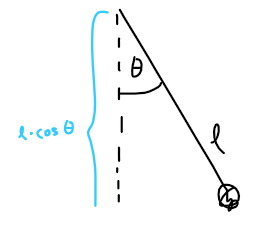

Wir wählen den Auslenkungswinkel $\theta(t)$ als generalisierte Koordinate für unser Pendel mit der Kantenlänge $\ell$. Dann ergibt sich als Hamiltonian

$$H(\theta, p_\theta) = p_\theta \dot \theta - L(\theta, \dot \theta),$$

welcher den generalisierten Impuls $p_\theta$ zugehörig zu $\theta$ verwendet mit dem Lagrangian

$$L(\theta, \dot \theta) = T(\theta, \dot \theta(p_\theta)) - U(\theta); \;\; T(\theta, \dot \theta) = \frac{1}{2}m (\dot \theta \cdot \ell)^2; \;\; U(\theta) = mg\ell \cdot cos\,\theta$$

aus dem wir per Definition $p_\theta$ erhalten, und sehen, dass er ein Drehimpuls ist: $Masse\;x\;Frequenz\;x\;Länge^2 = Länge\;x\;Masse\;x\;Geschwindigkeit$

$$ \begin{align} p_\theta &= \frac{\partial L}{\partial \dot p} = \frac{\partial T}{\partial \dot \theta} = \frac{1}{2} \frac{\partial(m\dot \theta^2\ell^2)}{\partial \dot \theta} = m \dot \theta \ell^2 \\ T(\theta, \dot \theta) &= \frac{m^2\theta^2\ell^4}{2m\ell^2}\\ \Leftrightarrow T(\theta, p_\theta) &= \frac{p_\theta^2}{2m\ell^2} \end{align} $$

direkt $$ \begin{align} H(\theta, p_\theta) &= p_\theta \cdot \dot \theta - \frac{p_\theta^2}{2m\ell^2} - mg\ell \cdot cos\,\theta\\ &= \frac{p_\theta^2}{2m\ell^2} - mg\ell \cdot cos\,\theta. \end{align} $$

Wir setzten den Hamiltonian $H(\theta, p)$ nun in die Hamiltongleichungen ein:

$$ \begin{align} \dot p_\theta &= - &\frac{\partial H}{\partial \theta} &\Rightarrow \dot p_\theta & = - \frac{\partial}{\partial \theta}\Big(\frac{p_\theta^2}{2m\ell^2} - mg\ell \cdot cos\,\theta\Big) \\ \dot \theta &= &\frac{\partial H}{\partial p} &\Rightarrow \dot \theta & = \frac{\partial}{\partial p_\theta}\Big(\frac{p_\theta^2}{2m\ell^2} - mg\ell \cdot cos\,\theta\Big) \end{align} $$

und erhalten

$$ \begin{align} \dot p_\theta & = - mg\ell \cdot sin\,\theta \\ \dot \theta & = \frac{p_\theta}{m\ell^2} \\ \Rightarrow \ddot \theta & = - \frac{mg\ell \cdot sin\,\theta}{m\ell^2} = - g\ell \cdot sin\,\theta \end{align} $$

Differenzialgleichungen. Mit diesen können wir nun zu einem Startzustand numerische Verfahren starten oder, da die Differenzialgleichung recht Simpel ist sie für einen gegebenen Startzustand lösen.